```python
import tensorflow as tf
import keras
from keras.preprocessing.image import ImageDataGenerator
from keras import layers, regularizers
import matplotlib.pyplot as plt
from sklearn.metrics import confusion_matrix
import pandas as pd
```

# Chess Piece Classifier

## 08/06/2021

### Goal: Create a chess piece classifier. Takes cropped images of single pieces and classifies the color and type of piece

## Loading the Data

We've taken and cropped images of all 12 pieces and "empty" squares

```python
images_folder = "CroppedImages"
img_height, img_width = 300, 180
batch_size = 16
targ_height = 100
targ_width = 90

# Data Generator with augmentation and scaling
data_gen = ImageDataGenerator(
    rescale=1./255,
    rotation_range=20,
    shear_range = .2,
    horizontal_flip=True,
    validation_split=0.3
)

# The Training Data
training_gen = data_gen.flow_from_directory(
    images_folder,
    target_size = (targ_height, targ_width),
    batch_size=batch_size,
    subset="training"
)

# The Validation Data
validation_gen = data_gen.flow_from_directory(
    images_folder,
    shuffle=False,
    target_size = (targ_height, targ_width),
    batch_size=batch_size,
    subset="validation"
)
```

```
Found 1365 images belonging to 13 classes.
Found 585 images belonging to 13 classes.
```

## Looking at the Data

We'll show a few of the images:

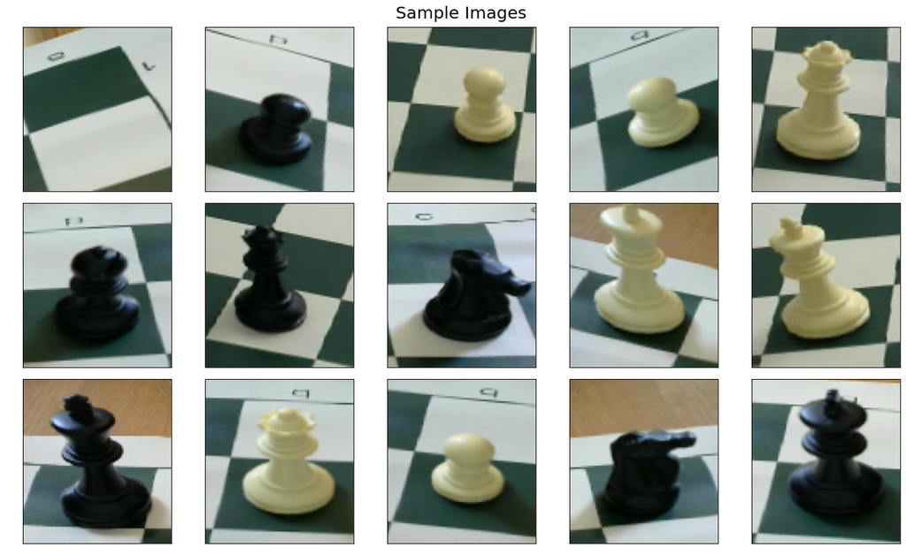

```python
rows, cols = 3, 5

fig = plt.figure(constrained_layout=True, figsize=(cols * 3, rows * 3))
subfigs = fig.subfigures(rows, 1 , wspace = .05)

axes = [
    subfig.subplots(1, cols)
    for subfig in subfigs
]

plt.suptitle("Sample Images", fontsize=20);

for ax in axes:
    for im in ax:
        im.imshow(training_gen.next()[0][0, :, :, :].reshape(targ_height, targ_width, 3))
        im.set_xticks([])
        im.set_yticks([])

training_gen.reset()
```

Note that 'empty' squares can still have bits of pieces in them if the neighboring square is populated.

I don't have enough training data - but it's a pain to make more data so here we are.

## Building our Classifier

Chess pieces (of a given color) look pretty similar.

Pieces have generally similar shapes, especially when considering that images are taken from slightly different angles. A picture of a king taken from a steep angle is very similar to a picture of a short pawn taken from a shallow angle.

Really only the 'head' of the piece is useful for identifying. So even though the input images are sized to 100x90, we need o extract as much detail as possible from the ~20x20 region with the piece's head. Our important feature is small, but very detailed.

To this end - our strategy is to stack a lot of convolution layers at the beginning, before any pooling occurs. Once pooling starts - and the fine detail of the piece head is lost - we pool very aggressively.

I tinkered with different classifiers - this is the best I managed

```python
model = keras.models.Sequential()

# We start with many convolutions in a row
model.add(layers.Conv2D(128, 5, activation='relu', input_shape=(targ_height, targ_width, 3)))
model.add(layers.Conv2D(140, 3, activation='relu'))
model.add(layers.Conv2D(150, 3, activation='relu'))
model.add(layers.Conv2D(160, 3, activation='relu'))
model.add(layers.Conv2D(170, 3, activation='relu'))
model.add(layers.Conv2D(180, 3, activation='relu'))
model.add(layers.BatchNormalization())
model.add(layers.MaxPooling2D(3))

model.add(layers.Conv2D(256, 3, activation='relu'))
model.add(layers.MaxPooling2D(3))

model.add(layers.Flatten())
model.add(layers.BatchNormalization())

model.add(layers.Dense(200, activation='relu', activity_regularizer=regularizers.l2(1e-5)))
model.add(layers.Dropout(.4))

model.add(layers.Dense(100, activation='relu', activity_regularizer=regularizers.l2(1e-5)))
model.add(layers.Dropout(.4))

# Output
model.add(layers.Dense(13, activation='softmax'))

model.compile(loss='categorical_crossentropy',
              optimizer="adam",
              metrics=['acc'])

model.summary()
```

```
Model: "sequential_2"
_________________________________________________________________
Layer (type)                 Output Shape              Param #
=================================================================
conv2d_7 (Conv2D)            (None, 96, 86, 128)       9728
_________________________________________________________________
conv2d_8 (Conv2D)            (None, 94, 84, 140)       161420
_________________________________________________________________
conv2d_9 (Conv2D)            (None, 92, 82, 150)       189150
_________________________________________________________________
conv2d_10 (Conv2D)           (None, 90, 80, 160)       216160
_________________________________________________________________
conv2d_11 (Conv2D)           (None, 88, 78, 170)       244970
_________________________________________________________________
conv2d_12 (Conv2D)           (None, 86, 76, 180)       275580
_________________________________________________________________
batch_normalization_2 (Batch (None, 86, 76, 180)       720
_________________________________________________________________
max_pooling2d_2 (MaxPooling2 (None, 28, 25, 180)       0
_________________________________________________________________
conv2d_13 (Conv2D)           (None, 26, 23, 256)       414976
_________________________________________________________________
max_pooling2d_3 (MaxPooling2 (None, 8, 7, 256)         0
_________________________________________________________________
flatten_1 (Flatten)          (None, 14336)             0
_________________________________________________________________
batch_normalization_3 (Batch (None, 14336)             57344
_________________________________________________________________
dense_3 (Dense)              (None, 200)               2867400
_________________________________________________________________
dropout_2 (Dropout)          (None, 200)               0
_________________________________________________________________
dense_4 (Dense)              (None, 100)               20100
_________________________________________________________________
dropout_3 (Dropout)          (None, 100)               0
_________________________________________________________________
dense_5 (Dense)              (None, 13)                1313
=================================================================
Total params: 4,458,861
Trainable params: 4,429,829
Non-trainable params: 29,032
_________________________________________________________________
```

[output not shown]

```python
# Training model - verbose set to 0 because it trains for a lot of epochs
training_hist = model.fit(
    training_gen,
    batch_size=batch_size,
    steps_per_epoch=630//batch_size,
    epochs=400,
    validation_data = validation_gen,
    validation_steps=270//batch_size,
    verbose=0
)
```

## Results

We construct a confusion matrix of the classifier results

```python
model = keras.models.load_model("ThirdAttempt")
model.summary()
evalu = model.evaluate(validation_gen)
results = model.predict(validation_gen)

predictions = list()
for i in range(len(validation_gen.labels)):
    predictions.append(results[i].tolist().index(max(results[i])))
labels = list(validation_gen.class_indices.keys())
cm = confusion_matrix(validation_gen.labels, predictions)
df_cm = pd.DataFrame(cm, index=labels, columns=labels)
df_cm
```

```
Model: "ThirdAttempt"
_________________________________________________________________
Layer (type)                 Output Shape              Param #
=================================================================
conv2d_53 (Conv2D)           (None, 96, 86, 128)       9728
_________________________________________________________________
conv2d_54 (Conv2D)           (None, 94, 84, 140)       161420
_________________________________________________________________
conv2d_55 (Conv2D)           (None, 92, 82, 150)       189150
_________________________________________________________________
conv2d_56 (Conv2D)           (None, 90, 80, 160)       216160
_________________________________________________________________
conv2d_57 (Conv2D)           (None, 88, 78, 170)       244970
_________________________________________________________________
conv2d_58 (Conv2D)           (None, 86, 76, 180)       275580
_________________________________________________________________
batch_normalization_14 (Batc (None, 86, 76, 180)       720
_________________________________________________________________
max_pooling2d_20 (MaxPooling (None, 28, 25, 180)       0
_________________________________________________________________
conv2d_59 (Conv2D)           (None, 26, 23, 256)       414976
_________________________________________________________________
max_pooling2d_21 (MaxPooling (None, 8, 7, 256)         0
_________________________________________________________________
flatten_7 (Flatten)          (None, 14336)             0
_________________________________________________________________
batch_normalization_15 (Batc (None, 14336)             57344
_________________________________________________________________
dense_21 (Dense)             (None, 200)               2867400
_________________________________________________________________
dropout_14 (Dropout)         (None, 200)               0
_________________________________________________________________
dense_22 (Dense)             (None, 100)               20100
_________________________________________________________________
dropout_15 (Dropout)         (None, 100)               0
_________________________________________________________________
dense_23 (Dense)             (None, 13)                1313
=================================================================
Total params: 4,458,861
Trainable params: 4,429,829
Non-trainable params: 29,032
_________________________________________________________________
```

|  | B-Bishop | B-King | B-Knight | B-Pawn | B-Queen | B-Rook | None | W-Bishop | W-King | W-Knight | W-Pawn | W-Queen | W-Rook |
| --- | --- | --- | --- | --- | --- | --- | --- | --- | --- | --- | --- | --- | --- |
| B-Bishop | 36 | 0 | 0 | 4 | 1 | 3 | 1 | 0 | 0 | 0 | 0 | 0 | 0 |
| B-King | 2 | 30 | 0 | 0 | 12 | 0 | 1 | 0 | 0 | 0 | 0 | 0 | 0 |
| B-Knight | 0 | 0 | 37 | 1 | 0 | 7 | 0 | 0 | 0 | 0 | 0 | 0 | 0 |
| B-Pawn | 2 | 0 | 4 | 35 | 0 | 1 | 3 | 0 | 0 | 0 | 0 | 0 | 0 |
| B-Queen | 11 | 3 | 0 | 0 | 27 | 4 | 0 | 0 | 0 | 0 | 0 | 0 | 0 |
| B-Rook | 0 | 0 | 0 | 0 | 0 | 45 | 0 | 0 | 0 | 0 | 0 | 0 | 0 |
| None | 0 | 1 | 1 | 0 | 0 | 0 | 43 | 0 | 0 | 0 | 0 | 0 | 0 |
| W-Bishop | 0 | 0 | 0 | 0 | 0 | 0 | 1 | 39 | 0 | 0 | 1 | 3 | 1 |
| W-King | 0 | 0 | 0 | 0 | 0 | 0 | 0 | 1 | 22 | 0 | 0 | 21 | 1 |
| W-Knight | 0 | 0 | 0 | 0 | 0 | 0 | 0 | 14 | 0 | 25 | 2 | 0 | 4 |
| W-Pawn | 0 | 0 | 0 | 0 | 0 | 0 | 3 | 0 | 0 | 0 | 42 | 0 | 0 |
| W-Queen | 0 | 0 | 0 | 0 | 0 | 0 | 0 | 3 | 1 | 0 | 0 | 41 | 0 |
| W-Rook | 0 | 0 | 0 | 0 | 0 | 0 | 0 | 0 | 0 | 0 | 0 | 0 | 45 |

- It never miscategorizes a pieces color!
- It easily confuses Kings and Queens. Unsurprising, given that they are both tall pieces, with almost identical bodies and a very minor differentiation in the 'crown'
- It does very well identifying empty squares.